# 13CH AD-AS Simulation

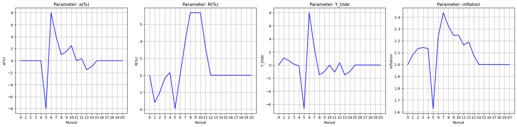

```python
# Has both models for CH13 & 12 model combined

import pandas as pd
from macrofunctions import calculate_inflation_stabilization_inflation, calculate_inflation_stabilization_sroutput, calculate_output_stabilization, calculate_taylor_rule_sroutput, calculate_taylor_rule_inflation, update_excel_df,  calculate_y_tilde, calculate_c_inflation, calculate_inflation, calculate_inflation1, calculate_SRY, calculate_Rt, plot_m_vs_period, plot_m_vs_period_Q, CH13_Short_Run_Output

parameters = {
    'Simulation Period (yrs)': 20,
    'a': 0.0,
    'a(%)': 0.0,
    'b': 0.68,
    'r(%)': 2.0,
    'R(%)': 2.0,
    'v': 0.076,
    'o(%)': 0.0,
    'm': 0.5,
    'n': 0.5,
    'pi_bar': 2,
    'fed_target_initial_inflation': 2.0
}
# 2020 =5, 2025 = 10, 2030 = 15, 2035 = 20.
quantitative_experiments = {
    'a(%)': [
        {'new_value': -8, 'time_period': 5, 'length': 1},
        {'new_value': 8, 'time_period': 6, 'length': 1},
        {'new_value': 4, 'time_period': 7, 'length': 1},
        {'new_value': 1, 'time_period': 8, 'length': 1},
        {'new_value': 1.5, 'time_period': 9, 'length': 1},
        {'new_value': 2.5, 'time_period': 10, 'length': 1},
        {'new_value': 0, 'time_period': 11, 'length': 1},
        {'new_value': .35, 'time_period': 12, 'length': 1},
        {'new_value': -1.5, 'time_period': 13, 'length': 1},
        {'new_value': -1, 'time_period': 14, 'length': 1}

    ],
    'R(%)': [
        {'new_value': .4, 'time_period': 1, 'length': 1},
        {'new_value': 1, 'time_period': 2, 'length': 1},
        {'new_value': 1.83, 'time_period': 3, 'length': 1},
        {'new_value': 2.16, 'time_period': 4, 'length': 1},
        {'new_value': .038, 'time_period': 5, 'length': 1},
        {'new_value': 2, 'time_period': 6, 'length': 1},
        {'new_value': 4, 'time_period': 7, 'length': 1},
        {'new_value': 5.68, 'time_period': 8, 'length': 3},
        {'new_value': 3.6045, 'time_period': 11, 'length': 1}
    ]
} # to add just use the same format & change parameter

# Initialize the DataFrame
num_periods = parameters['Simulation Period (yrs)'] + 1
df = pd.DataFrame({
    'Period': range(num_periods),
    'a': [parameters['a']] * num_periods,
    'a(%)': [parameters['a(%)']] * num_periods,
    'b': [parameters['b']] * num_periods,
    'r(%)': [parameters['r(%)']] * num_periods,
    'R(%)': [parameters['R(%)']] * num_periods,
    'v': [parameters['v']] * num_periods,
    'o(%)': [parameters['o(%)']] * num_periods,
    'm': [parameters['m']] * num_periods,
    'n': [parameters['n']] * num_periods,
    'pi_bar': [parameters['pi_bar']] * num_periods,
    'Inflation Stabilization sroutput': [0.0] * num_periods,
    'Inflation Stabilization inflation': [parameters['fed_target_initial_inflation']] * num_periods,
    'Output Stabilization sroutput': [0.0] * num_periods,
    'Output Stabilization inflation': [parameters['fed_target_initial_inflation']] * num_periods,
    'Taylor Rule sroutput': [0.0] * num_periods,
    'Taylor Rule inflation': [parameters['fed_target_initial_inflation']] * num_periods,
    'Y_tilde': [0.0] * num_periods,
    'c_inflation': [0.0] * num_periods,
    'inflation': [parameters['fed_target_initial_inflation']] * num_periods,
    'inflation_13CH': [0.0] * num_periods,
    'SRY': [0.0] * num_periods,
    'Rt': [0.0] * num_periods
})

# Convert columns to numeric type explicitly
numeric_columns = ['a(%)', 'b', 'r(%)', 'R(%)', 'v', 'o(%)', 'm', 'n', 'Inflation Stabilization sroutput', 'Inflation Stabilization inflation', 'Output Stabilization sroutput', 'Output Stabilization inflation', 'Taylor Rule sroutput', 'Taylor Rule inflation', 'Y_tilde', 'c_inflation', 'inflation', 'inflation_13CH', 'SRY', 'Rt']
df[numeric_columns] = df[numeric_columns].apply(pd.to_numeric)

date_columns = []
for col in date_columns:
    df[col] = pd.to_datetime(df[col]).dt.date

# Apply Quantitative Experiments
for param, changes_list in quantitative_experiments.items():
    for changes in changes_list:
        for period in range(changes['time_period'], changes['time_period'] + changes['length']):
            if period < num_periods:
                df.at[period, param] = changes['new_value']

# Apply the calculations to each row in the DataFrame
for i in range(len(df)):

    inflation = calculate_inflation_stabilization_inflation(df, i, parameters['fed_target_initial_inflation']) # inflation stabilization inflation
    df.at[i, 'Inflation Stabilization inflation'] = inflation

    sroutput = calculate_inflation_stabilization_sroutput(df, i, parameters['fed_target_initial_inflation']) # inflation stabilization sroutput
    df.at[i, 'Inflation Stabilization sroutput'] = sroutput

    sroutput, inflation = calculate_output_stabilization(df, i, parameters['fed_target_initial_inflation']) # Output Stabilization
    df.at[i, 'Output Stabilization sroutput'] = sroutput
    df.at[i, 'Output Stabilization inflation'] = inflation

    sroutput = calculate_taylor_rule_sroutput(df, i, parameters['fed_target_initial_inflation']) # Taylor Rule sroutput
    df.at[i, 'Taylor Rule sroutput'] = sroutput

    inflation = calculate_taylor_rule_inflation(df, i, parameters['fed_target_initial_inflation']) # Taylor Rule inflation
    df.at[i, 'Taylor Rule inflation'] = inflation

    # Calculate Y_tilde
    Y_tilde = calculate_y_tilde(df, i)
    df.at[i, 'Y_tilde'] = Y_tilde

    # Calculate c_inflation
    c_inflation = calculate_c_inflation(df, i)
    df.at[i, 'c_inflation'] = c_inflation

    # Calculate inflation
    inflation = calculate_inflation(df, i, parameters['fed_target_initial_inflation'])
    df.at[i, 'inflation'] = inflation

    # 13 class example
    inflation = calculate_inflation1(df, i, parameters['b'], parameters['m'], parameters['v'], parameters['pi_bar'])
    df.at[i, 'inflation_13CH'] = inflation

    # 13 class example
    SRY = calculate_SRY(df, i, parameters['b'], parameters['m'], parameters['v'], parameters['pi_bar'])
    df.at[i, 'SRY'] = SRY

    # 13 class example
    Rt = calculate_Rt(df, i, parameters['m'])
    df.at[i, 'Rt'] = Rt

# update_excel_df("C://Users//eduar//OneDrive - BYU-Idaho//Desktop//Coding//Macro//macrodata.xlsx", df)

# display
# display(df.head(20))
plot_m_vs_period(df, ['a(%)', 'R(%)', 'Y_tilde', 'inflation'], x_tick_interval=1) # , x_tick_interval=2
```

# Part 2.3

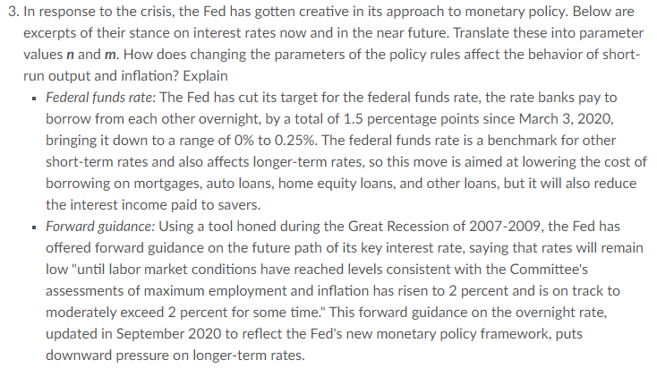

13CH Should do Part 2.3

**In response to the crisis, the Fed has gotten creative in its approach to monetary policy. Below are excerpts of their stance on interest rates now and in the near future. Translate these into parameter values n and m. How does changing the parameters of the policy rules affect the behavior of short-run output and inflation? Explain**

**Federal funds rate: The Fed has cut its target for the federal funds rate, the rate banks pay to borrow from each other overnight, by a total of 1.5 percentage points since March 3, 2020, bringing it down to a range of 0% to 0.25%. The federal funds rate is a benchmark for other short-term rates and also affects longer-term rates, so this move is aimed at lowering the cost of borrowing on mortgages, auto loans, home equity loans, and other loans, but it will also reduce the interest income paid to savers.**

**Forward guidance: Using a tool honed during the Great Recession of 2007-2009, the Fed has offered forward guidance on the future path of its key interest rate, saying that rates will remain low “until labor market conditions have reached levels consistent with the Committee’s assessments of maximum employment and inflation has risen to 2 percent and is on track to moderately exceed 2 percent for some time.” This forward guidance on the overnight rate, updated in September 2020 to reflect the Fed’s new monetary policy framework, puts downward pressure on longer-term rates.**

Back to top